# Collective Narcissism IRT

M. Murat Ardag

11/26/2019

# Short Collective Narcissism Scale: An Item Response Theory Analysis

Previous research has shown the involvement of collective narcissism (Golec de Zavala, Cichocka, Eidelson, & Jayawickreme, 2009) in various intergroup relations. The short ((Golec de Zavala, 2011) 5-items) version of the scale has been used in different cultural and national contexts and has persistently shown concurrent and predictive validity (Golec de Zavala, Dyduch-Hazar, & Lantos, 2019).

The following analyses outline an item response theory approach for item reduction. Parsimony dictates fewer number of items in measurement instruments; this is particularly desirable for researchers since very short scales are cost-effective and have a less cognitive load for the participants.

The analyses utilizes a pooled sample of Polish (*N* = 1428; 33%), German (*N* = 2223; 52%) and Turkish participants (*N* = 654; 15%). 47 % of the sample is female; average age is 35.23 (*SD* = 15.31; *Md* = 29). The dataset also includes the normalized political orientation scores; *M*=0.43, *SD* = 0.26, *Md* = 0.4. The short version of the Collective Narcissism scale is used in the analyses; responses reflect how participants feel about their national in-group. Further item-level descriptive statistics are provided at the end of the blog post.

The full and the short Collective Narcissism scale can be accessed from [this link](https://collectivenarcissism.com/resources). We start by seeing the item-level psychometric properties of the short collective narcissism scale with the item information curves (IIC) and the category characteristic curves (CCC). For both plots, the x-axis represents the latent trait continuum. The y-axis I(θ) on the IIC represent the information, which can roughly be thought of as the discriminant ability of the item to differentiate individuals on the latent continuum. Here, narrow and high information curves are desirable, falling on different levels of the latent space.

In the following plot, we see that the short collective narcissism items mostly capture the information for the moderate (leaning towards the center) levels since all items peak around 0, and the intervals are roughly -2 & 2. Items with the highest information are cn2 and cn3, followed by cn5 and cn9 (see the Discrimination parameter column in the table below). Although picking the most informative items would not be a wrong strategy for shortening the scale, one can also take into account the category thresholds that accompany the information. In this sense, one can also go with cn9 instead of cn5 because it has a higher threshold on β6 (1.727), that is the threshold between answering with the highest ordered response category rather than all other response categories combined. Such property signals that this item requires a higher level of collective narcissism for its endorsement.

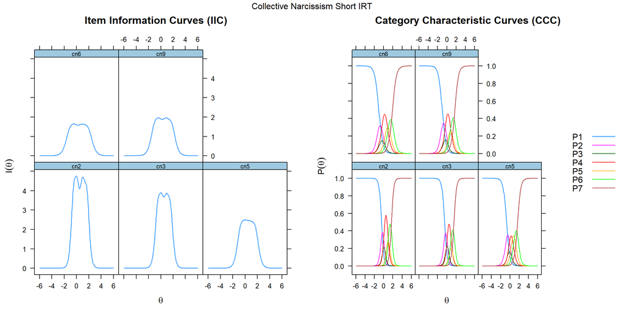

| Discrimination parameters and category thresholds for Collective Narcissism short |  |  |  |  |  |  |  |
| --- | --- | --- | --- | --- | --- | --- | --- |
|  | Discrimination | Category Thresholds |  |  |  |  |  |
|  | α | β1 | β2 | β3 | β4 | β5 | β6 |
| cn2 | 3.915 | -0.481 | -0.065 | 0.152 | 0.829 | 1.131 | 1.663 |
| cn3 | 3.529 | -0.499 | -0.052 | 0.204 | 0.795 | 1.026 | 1.525 |
| cn5 | 2.806 | -0.744 | -0.219 | 0.015 | 0.525 | 1.036 | 1.643 |
| cn6 | 2.292 | -1.056 | -0.477 | -0.216 | 0.627 | 1.17 | 1.887 |
| cn9 | 2.502 | -0.993 | -0.411 | -0.161 | 0.619 | 1.035 | 1.727 |

The other item-level property, category characteristic curves (CCC), provides the cumulative probability of endorsing a particular response category compared to any other response category such as 1 vs. 2,3,4,5,6,7 or 1,2 vs. 3,4,5,6,7, etc. The y-axis P(θ) here corresponds to this cumulative probability. Since the assumption is these response categories being ordered (but not necessarily in equal intervals), ideally, we expect to see the first and the last curves (P1 & P7) having the S shape and all those in-between not being over 50 % in an orderly fashion. The visual heuristic below indicates that the short collective narcissism scale does not divert severely from this pattern. Therefore we can somewhat conclude that the seven response categories do their job well, and there is no need to alter these options.

Below is the suggested ultra-short version of the Collective Narcissism scale (cn2, cn3, cn9). Although IIC characteristics do not mimic the same pattern in the 5-items version, the CCC characteristics are still pretty acceptable.

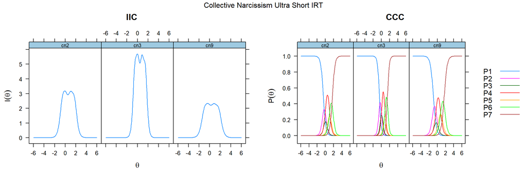

We can start testing the Collective Narcissism scale’s ultra-short version with the scale-level properties. The first row of the figure below shows the properties of the short version; the second row has the ultra-short version properties. Test Information (TI) & Standard Error (SE) plots reveal that the error approaches zero within the captured latent trait range in both versions of the scale. Since the number of items are reduced in the ultra-short version, the information I(θ) is less. However, the pattern does not change; the range is still roughly between -2 – 3 on the latent trait continuum. These cues suggest that the ultra-short version is likely to be not worse than the short version. The same inference is relevant for the TCCs. Here, the desired visual cue is again the logistic function sigmoid curve indicating that on the scale level, ultra-short collective narcissism scale is as good as the short version and is still capable of providing the means of transforming latent trait scores to true scores.

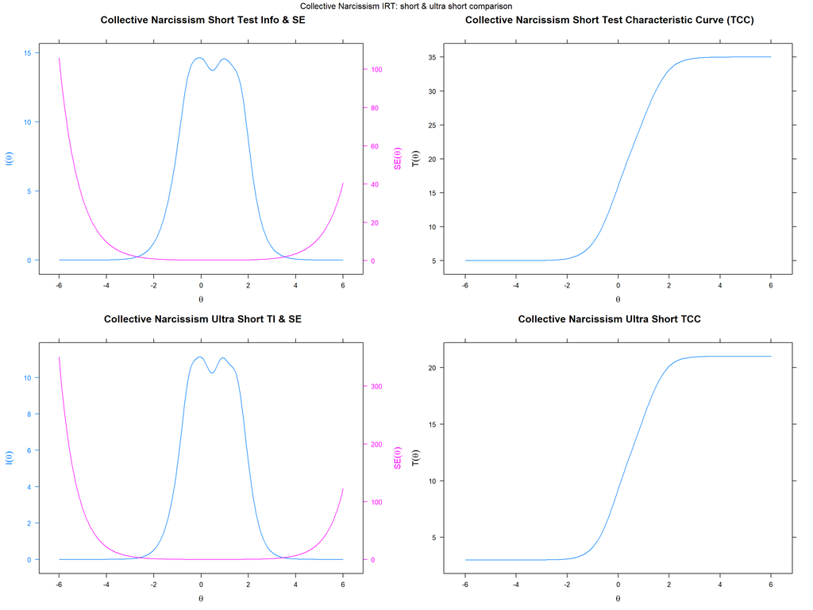

If we were to quantify these properties with the scale reliability, we see that the ultra-short version loses only a negligible degree with the item-reduction - see the Test Information plots below; reliabilities are printed on the right.

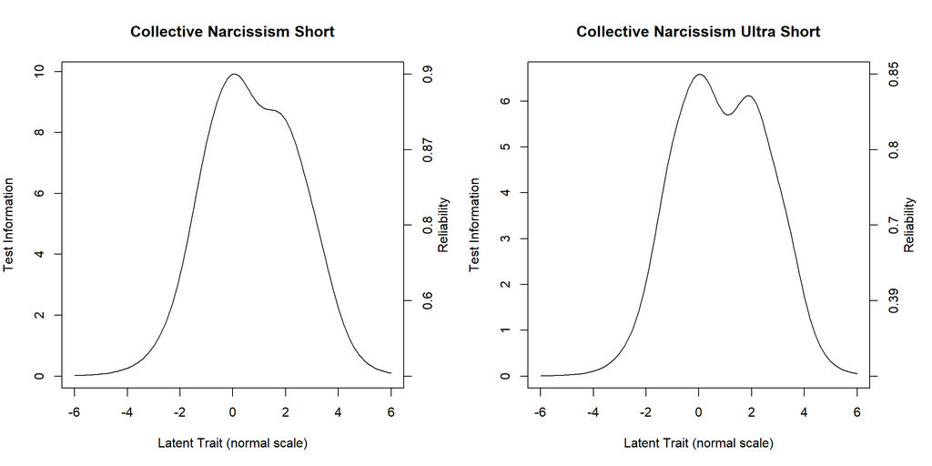

At this point, it is important to note the differences in score calculations. Simply adding up the items or taking a mean might bias the results in any version of the scale since the latent trait of collective narcissism is clearly not influencing these items with the same degree. Researchers who are familiar with the confirmatory factor analysis measurement models are already aware of this since the factor loadings are almost always different from one another. Therefore, we suggest a score calculation strategy that acknowledges the different influence of the latent construct on the items. Although there is no magic formula here, we suggest relying on either the IRT factor scores or the factor scores from the CFA (either raw or normalized).

Below is the follow-up analyses done with the IRT factor scores. The correlation coefficient between the short version and ultra-short version scores is 0.97 (CI: 0.96 – 0.97 p<.001). Both scores follow very similar patterns across gender and country. Although the latter argument is not an empirical verification, it is again an indication that the performance of the ultra-short version is not different from the short version.

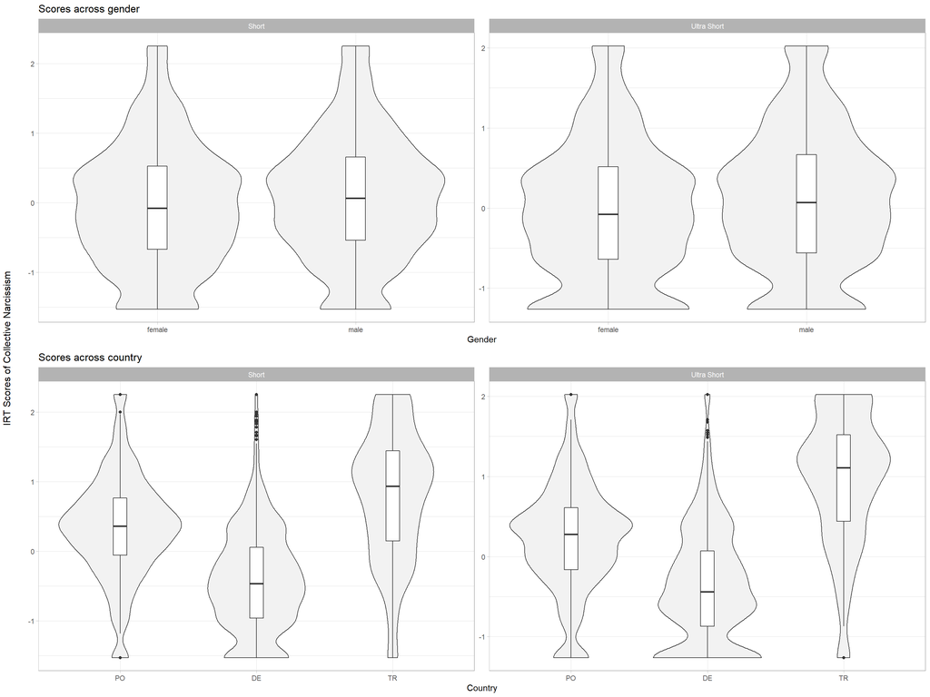

When we put the ultra-short version of the Collective Narcissism Scale into an empirical test by seeing its association with age and gender, we see that the statistical significance is not different for both versions. OLS regression results are displayed in the table below. All changes across the age intervals are significant except the >80; also, males have significantly higher scores compared to females.

|  | IRT Scores of Collective Narcissism Short |  |  |  |  | IRT Scores of Collective Narcissism Ultra-Short |  |  |  |  |
| --- | --- | --- | --- | --- | --- | --- | --- | --- | --- | --- |
| Coefficient | Estimates | std. Error | CI (95%) | Statistic | P-Value | Estimates | std. Error | CI (95%) | Statistic | P-Value |
| Intercept | -0.31 | 0.03 | -0.36 – -0.26 | -11.64 | **<0.001** | -0.28 | 0.03 | -0.33 – -0.23 | -11.03 | **<0.001** |
| Age: 30-39 compared to 18-29 | 0.19 | 0.04 | 0.11 – 0.28 | 4.45 | **<0.001** | 0.17 | 0.04 | 0.08 – 0.25 | 3.92 | **<0.001** |
| Age: 40-49 compared to 18-29 | 0.65 | 0.05 | 0.56 – 0.74 | 14.05 | **<0.001** | 0.58 | 0.05 | 0.49 – 0.67 | 12.86 | **<0.001** |
| Age: 50-59 compared to 18-29 | 0.46 | 0.05 | 0.36 – 0.56 | 9.03 | **<0.001** | 0.43 | 0.05 | 0.33 – 0.53 | 8.74 | **<0.001** |
| Age: 60-69 compared to 18-29 | 0.43 | 0.06 | 0.31 – 0.55 | 7.03 | **<0.001** | 0.43 | 0.06 | 0.31 – 0.54 | 7.25 | **<0.001** |
| Age: 70-79 compared to 18-29 | 0.42 | 0.11 | 0.21 – 0.63 | 3.95 | **<0.001** | 0.38 | 0.10 | 0.18 – 0.58 | 3.73 | **<0.001** |
| Age: >80 compared to 18-29 | 0.12 | 0.20 | -0.28 – 0.52 | 0.59 | 0.555 | 0.22 | 0.20 | -0.17 – 0.61 | 1.10 | 0.272 |
| Males compared to Females | 0.11 | 0.03 | 0.04 – 0.17 | 3.38 | **0.001** | 0.14 | 0.03 | 0.08 – 0.19 | 4.48 | **<0.001** |
| Observations | 3132 |  |  |  |  | 3132 |  |  |  |  |
| R<sup>2</sup> / R<sup>2</sup> adjusted | 0.082 / 0.080 |  |  |  |  | 0.078 / 0.076 |  |  |  |  |

The following plots visualize the results.

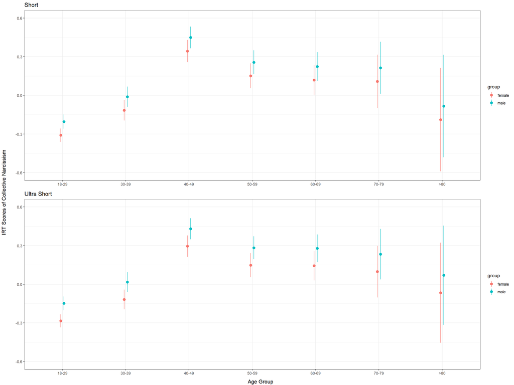

The predictive validity of the ultra-short version is also as good as the short version. The following path analyses results reveal that both versions of the scale have significant associations with the political orientation scores.

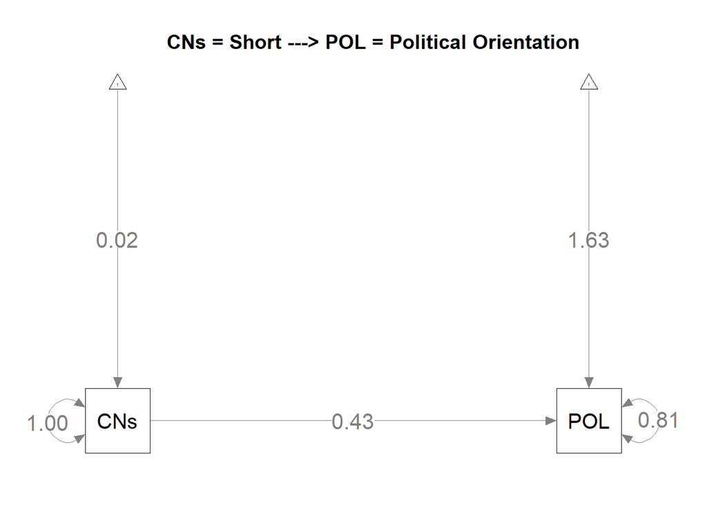

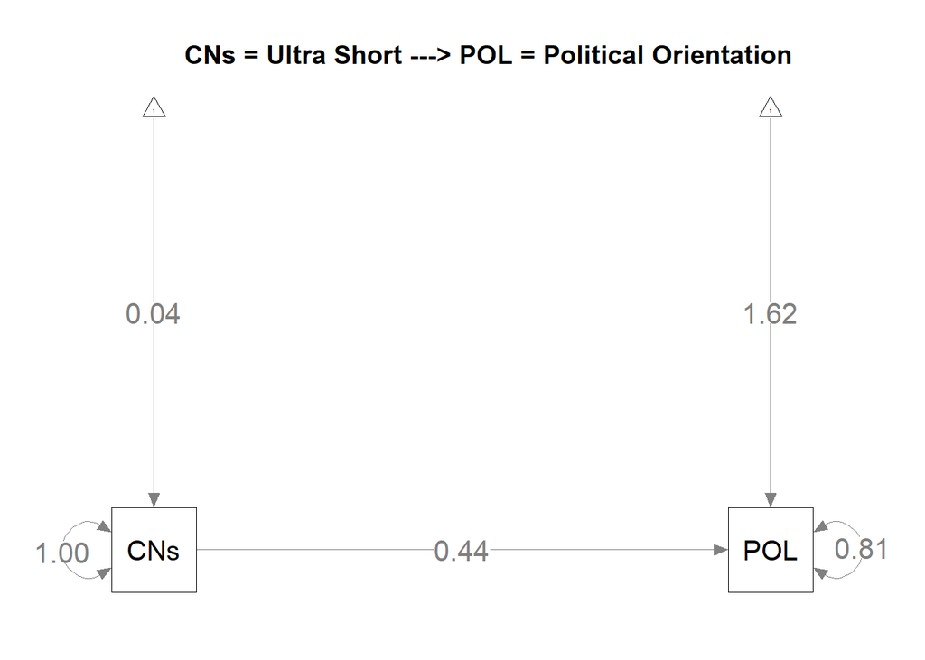

Short Scale

| Outcome | Indicator | B | SE | Z | Beta | sig |
| --- | --- | --- | --- | --- | --- | --- |
| POLRn | CNsh | 0.125 | 0.004 | 28.884 | 0.433 | *** |

Ultra Short Scale

| Outcome | Indicator | B | SE | Z | Beta | sig |
| --- | --- | --- | --- | --- | --- | --- |
| POLRn | CNush | 0.132 | 0.005 | 29.297 | 0.44 | *** |

We can check the cross-cultural validity in multiple ways. The conventional practice in cross-cultural psychology dictates starting with a multi-group confirmatory factor analysis. Though, this approach is known to be very strict since it assumes and tests for the exact measurement invariance, which is so very hard to achieve in reality (Davidov, Meuleman, Cieciuch, Schmidt, & Billiet, 2014). Neither the short version nor the very-short version passes this test. Below is the results only for the ultra-short version of the scale; the Fit Measures Testing table displays the goodness of fit statistics of the models going from configural to strict scalar. Consecutive tests show that the stricter models fit the data worse, indicating no exact measurement invariance. Path diagrams for the configural CFAs are also displayed (PO: left, DE: middle, TR: right).

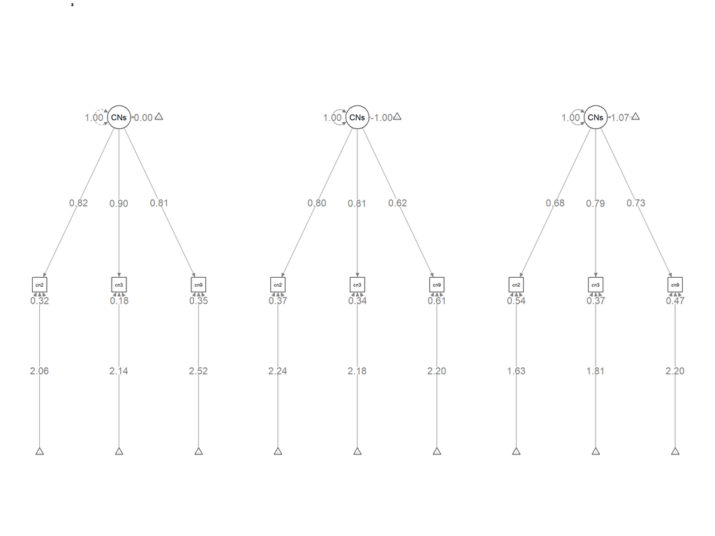

Fit measures testing

|  | RMSEA Robust | CI low | CI up | SRMR | CFI Robust | Chi2 | df | p |
| --- | --- | --- | --- | --- | --- | --- | --- | --- |
| Configural Invariance | 0.223 | 0.207 | 0.239 | 0.142 | 0.894 | 579.594 | 8 | 0 |
| Metric Invariance | 0.237 | 0.222 | 0.253 | 0.094 | 0.881 | 653.859 | 8 | 0 |
| Scalar Invariance | 0.237 | 0.222 | 0.253 | 0.094 | 0.881 | 653.859 | 8 | 0 |
| Strict Invariance | 0.362 | 0.348 | 0.377 | 0.393 | 0.652 | 1895.364 | 10 | 0 |

Follow-up analyses with the frequentist alignment technique (Asparouhov & Muthén, 2014) suggest a low degree of cross-cultural validity. Here, the effect sizes of approximate invariance based on the $R^2$ can be used as an indicator. A metric invariance of equal factor loadings across groups would correspond to an $R^2$ of 1. The ultra-short version of the Collective Narcissism scale in the current sample has 99.6 % with 11.1 % in noninvariance in item parameters (when parameter tolerance value = 0.2). Scalar invariance would require an $R^2$ of 1 for the loadings plus an $R^2$ of 1 for the intercepts. The sample in this analysis has 99.1 % for the intercepts; however the percentage of the noninvariant item parameters is 33.3% (when parameter tolerance value = 0.2), which go over the recommended 25 %. Given the exact and the approximate invariance results, extreme caution is suggested for the cross-cultural-validity of the short and ultra-short versions of the Collective Narcissism scale.

The overall results provide evidence that the suggested 3-items ultra-short version of the Collective Narcissism scale performs as well as the 5-items short-version, which makes it an acceptable and practically useful instrument. Below are the item wordings in English.

### Suggested items for the ultra-short version

| Variable Abbreviation | Item Wording |
| --- | --- |
| cn2: | My group deserves special treatment |
| cn3: | Not many people seem to fully understand the importance of my group |
| cn9: | I will never be satisfied until my group gets the recognition it deserves |

# Item-level descriptive statistics by country

Descriptive Statistics: Pooled sample & by country

| variable | n | mean | sd | median | trimmed | mad | min | max | range | skew | kurtosis | se |
| --- | --- | --- | --- | --- | --- | --- | --- | --- | --- | --- | --- | --- |
| Age | 3616 | 35.23 | 15.31 | 29.0 | 33.29 | 11.86 | 14 | 91 | 77 | 0.97 | 0.00 | 0.25 |
| cn2 | 4305 | 3.06 | 1.93 | 3.0 | 2.86 | 2.97 | 1 | 7 | 6 | 0.52 | -0.90 | 0.03 |
| cn3 | 4305 | 3.15 | 2.02 | 3.0 | 2.95 | 2.97 | 1 | 7 | 6 | 0.51 | -1.00 | 0.03 |
| cn5 | 4305 | 3.39 | 1.99 | 3.0 | 3.26 | 2.97 | 1 | 7 | 6 | 0.28 | -1.20 | 0.03 |
| cn6 | 4305 | 3.56 | 1.84 | 4.0 | 3.49 | 2.97 | 1 | 7 | 6 | 0.12 | -1.00 | 0.03 |
| cn9 | 4305 | 3.60 | 1.90 | 4.0 | 3.52 | 2.97 | 1 | 7 | 6 | 0.14 | -1.07 | 0.03 |
| Political Orientation | 4261 | 0.43 | 0.26 | 0.4 | 0.42 | 0.30 | 0 | 1 | 1 | 0.36 | -0.59 | 0.00 |
| **Poland** |  |  |  |  |  |  |  |  |  |  |  |  |
| Age | 927 | 41.81 | 13.30 | 42.0 | 41.32 | 14.83 | 18 | 77 | 59 | 0.30 | -0.62 | 0.44 |
| cn2 | 1428 | 3.86 | 1.66 | 4.0 | 3.87 | 1.48 | 1 | 7 | 6 | -0.01 | -0.62 | 0.04 |
| cn3 | 1428 | 3.45 | 1.63 | 4.0 | 3.38 | 1.48 | 1 | 7 | 6 | 0.24 | -0.52 | 0.04 |
| cn5 | 1428 | 4.52 | 1.64 | 5.0 | 4.59 | 1.48 | 1 | 7 | 6 | -0.40 | -0.55 | 0.04 |
| cn6 | 1428 | 4.25 | 1.55 | 4.0 | 4.30 | 1.48 | 1 | 7 | 6 | -0.25 | -0.32 | 0.04 |
| cn9 | 1428 | 3.71 | 1.59 | 4.0 | 3.71 | 1.48 | 1 | 7 | 6 | -0.02 | -0.52 | 0.04 |
| Political Orientation | 1428 | 0.43 | 0.22 | 0.5 | 0.42 | 0.30 | 0 | 1 | 1 | 0.28 | -0.21 | 0.01 |
| **Germany** |  |  |  |  |  |  |  |  |  |  |  |  |
| Age | 2175 | 32.22 | 15.34 | 26.0 | 29.42 | 7.41 | 18 | 91 | 73 | 1.52 | 1.38 | 0.33 |
| cn2 | 2223 | 2.13 | 1.52 | 1.0 | 1.88 | 0.00 | 1 | 7 | 6 | 1.27 | 0.84 | 0.03 |
| cn3 | 2223 | 2.25 | 1.64 | 1.0 | 1.96 | 0.00 | 1 | 7 | 6 | 1.20 | 0.46 | 0.03 |
| cn5 | 2223 | 2.38 | 1.62 | 2.0 | 2.13 | 1.48 | 1 | 7 | 6 | 1.01 | 0.07 | 0.03 |
| cn6 | 2223 | 2.94 | 1.67 | 3.0 | 2.80 | 1.48 | 1 | 7 | 6 | 0.41 | -0.86 | 0.04 |
| cn9 | 2223 | 3.05 | 1.80 | 3.0 | 2.89 | 1.48 | 1 | 7 | 6 | 0.44 | -0.92 | 0.04 |
| Political Orientation | 2180 | 0.39 | 0.26 | 0.4 | 0.38 | 0.30 | 0 | 1 | 1 | 0.46 | -0.55 | 0.01 |
| **Turkey** |  |  |  |  |  |  |  |  |  |  |  |  |
| Age | 514 | 36.11 | 14.72 | 33.0 | 34.83 | 16.31 | 14 | 77 | 63 | 0.57 | -0.92 | 0.65 |
| cn2 | 654 | 4.46 | 2.10 | 5.0 | 4.57 | 2.97 | 1 | 7 | 6 | -0.30 | -1.33 | 0.08 |
| cn3 | 654 | 5.54 | 1.81 | 6.0 | 5.88 | 1.48 | 1 | 7 | 6 | -1.36 | 0.75 | 0.07 |
| cn5 | 654 | 4.33 | 2.07 | 5.0 | 4.42 | 2.97 | 1 | 7 | 6 | -0.22 | -1.33 | 0.08 |
| cn6 | 654 | 4.19 | 2.17 | 4.0 | 4.24 | 2.97 | 1 | 7 | 6 | -0.15 | -1.41 | 0.08 |
| cn9 | 654 | 5.24 | 1.87 | 6.0 | 5.51 | 1.48 | 1 | 7 | 6 | -1.02 | -0.13 | 0.07 |
| Political Orientation | 653 | 0.52 | 0.31 | 0.5 | 0.53 | 0.44 | 0 | 1 | 1 | -0.02 | -1.19 | 0.01 |

## Scale reliability – pooled sample including the Polish, German & Turkish samples

Component 1

| Row | Missings | Mean | SD | Skew | W(p) | Item Difficulty | Item Discrimination | α if deleted |  |
| --- | --- | --- | --- | --- | --- | --- | --- | --- | --- |
| cn2 | 0.00 % | 3.06 | 1.93 | 0.52 | 0.87 (0.000) | 0.44 | 0.809 | 0.866 |  |
| cn3 | 0.00 % | 3.15 | 2.02 | 0.51 | 0.87 (0.000) | 0.45 | 0.787 | 0.871 |  |
| cn5 | 0.00 % | 3.39 | 1.99 | 0.28 | 0.89 (0.000) | 0.48 | 0.752 | 0.879 |  |
| cn6 | 0.00 % | 3.56 | 1.84 | 0.12 | 0.92 (0.000) | 0.51 | 0.694 | 0.891 |  |
| cn9 | 0.00 % | 3.6 | 1.9 | 0.14 | 0.92 (0.000) | 0.51 | 0.724 | 0.885 |  |
| Mean inter-item-correlation=0.644 · Cronbach’s α=0.901 |  |  |  |  |  |  |  |  |  |

Component 1

| Row | Missings | Mean | SD | Skew | W(p) | Item Difficulty | Item Discrimination | α if deleted |  |
| --- | --- | --- | --- | --- | --- | --- | --- | --- | --- |
| cn2 | 0.00 % | 3.06 | 1.93 | 0.52 | 0.87 (0.000) | 0.44 | 0.752 | 0.819 |  |
| cn3 | 0.00 % | 3.15 | 2.02 | 0.51 | 0.87 (0.000) | 0.45 | 0.784 | 0.789 |  |
| cn9 | 0.00 % | 3.6 | 1.9 | 0.14 | 0.92 (0.000) | 0.51 | 0.724 | 0.843 |  |
| Mean inter-item-correlation=0.692 · Cronbach’s α=0.871 |  |  |  |  |  |  |  |  |  |

### Polish sample

Component 1

| Row | Missings | Mean | SD | Skew | W(p) | Item Difficulty | Item Discrimination | α if deleted |  |
| --- | --- | --- | --- | --- | --- | --- | --- | --- | --- |
| cn2 | 0.00 % | 3.86 | 1.66 | -0.01 | 0.94 (0.000) | 0.55 | 0.817 | 0.9 |  |
| cn3 | 0.00 % | 3.45 | 1.63 | 0.24 | 0.93 (0.000) | 0.49 | 0.825 | 0.898 |  |
| cn5 | 0.00 % | 4.52 | 1.64 | -0.4 | 0.94 (0.000) | 0.65 | 0.753 | 0.913 |  |
| cn6 | 0.00 % | 4.25 | 1.55 | -0.25 | 0.94 (0.000) | 0.61 | 0.788 | 0.906 |  |
| cn9 | 0.00 % | 3.71 | 1.59 | -0.02 | 0.93 (0.000) | 0.53 | 0.803 | 0.903 |  |
| Mean inter-item-correlation=0.703 · Cronbach’s α=0.922 |  |  |  |  |  |  |  |  |  |

Component 1

| Row | Missings | Mean | SD | Skew | W(p) | Item Difficulty | Item Discrimination | α if deleted |  |
| --- | --- | --- | --- | --- | --- | --- | --- | --- | --- |
| cn2 | 0.00 % | 3.86 | 1.66 | -0.01 | 0.94 (0.000) | 0.55 | 0.796 | 0.854 |  |
| cn3 | 0.00 % | 3.45 | 1.63 | 0.24 | 0.93 (0.000) | 0.49 | 0.809 | 0.843 |  |
| cn9 | 0.00 % | 3.71 | 1.59 | -0.02 | 0.93 (0.000) | 0.53 | 0.786 | 0.862 |  |
| Mean inter-item-correlation=0.744 · Cronbach’s α=0.897 |  |  |  |  |  |  |  |  |  |

### German sample

Component 1

| Row | Missings | Mean | SD | Skew | W(p) | Item Difficulty | Item Discrimination | α if deleted |  |
| --- | --- | --- | --- | --- | --- | --- | --- | --- | --- |
| cn2 | 0.00 % | 2.13 | 1.52 | 1.27 | 0.75 (0.000) | 0.3 | 0.677 | 0.805 |  |
| cn3 | 0.00 % | 2.25 | 1.64 | 1.2 | 0.76 (0.000) | 0.32 | 0.74 | 0.786 |  |
| cn5 | 0.00 % | 2.38 | 1.62 | 1.01 | 0.81 (0.000) | 0.34 | 0.664 | 0.807 |  |
| cn6 | 0.00 % | 2.94 | 1.67 | 0.41 | 0.89 (0.000) | 0.42 | 0.546 | 0.839 |  |
| cn9 | 0.00 % | 3.05 | 1.8 | 0.44 | 0.89 (0.000) | 0.44 | 0.633 | 0.817 |  |
| Mean inter-item-correlation=0.522 · Cronbach’s α=0.843 |  |  |  |  |  |  |  |  |  |

Component 1

| Row | Missings | Mean | SD | Skew | W(p) | Item Difficulty | Item Discrimination | α if deleted |  |
| --- | --- | --- | --- | --- | --- | --- | --- | --- | --- |
| cn2 | 0.00 % | 2.13 | 1.52 | 1.27 | 0.75 (0.000) | 0.3 | 0.653 | 0.717 |  |
| cn3 | 0.00 % | 2.25 | 1.64 | 1.2 | 0.76 (0.000) | 0.32 | 0.682 | 0.681 |  |
| cn9 | 0.00 % | 3.05 | 1.8 | 0.44 | 0.89 (0.000) | 0.44 | 0.6 | 0.776 |  |
| Mean inter-item-correlation=0.574 · Cronbach’s α=0.797 |  |  |  |  |  |  |  |  |  |

### Turkish sample

Component 1

| Row | Missings | Mean | SD | Skew | W(p) | Item Difficulty | Item Discrimination | α if deleted |  |
| --- | --- | --- | --- | --- | --- | --- | --- | --- | --- |
| cn2 | 0.00 % | 4.46 | 2.1 | -0.3 | 0.88 (0.000) | 0.64 | 0.778 | 0.831 |  |
| cn3 | 0.00 % | 5.54 | 1.81 | -1.36 | 0.76 (0.000) | 0.79 | 0.631 | 0.866 |  |
| cn5 | 0.00 % | 4.33 | 2.07 | -0.22 | 0.90 (0.000) | 0.62 | 0.7 | 0.851 |  |
| cn6 | 0.00 % | 4.19 | 2.17 | -0.15 | 0.88 (0.000) | 0.6 | 0.731 | 0.843 |  |
| cn9 | 0.00 % | 5.24 | 1.87 | -1.02 | 0.82 (0.000) | 0.75 | 0.694 | 0.852 |  |
| Mean inter-item-correlation=0.585 · Cronbach’s α=0.876 |  |  |  |  |  |  |  |  |  |

Component 1

| Row | Missings | Mean | SD | Skew | W(p) | Item Difficulty | Item Discrimination | α if deleted |  |
| --- | --- | --- | --- | --- | --- | --- | --- | --- | --- |
| cn2 | 0.00 % | 4.46 | 2.1 | -0.3 | 0.88 (0.000) | 0.64 | 0.668 | 0.747 |  |
| cn3 | 0.00 % | 5.54 | 1.81 | -1.36 | 0.76 (0.000) | 0.79 | 0.647 | 0.764 |  |
| cn9 | 0.00 % | 5.24 | 1.87 | -1.02 | 0.82 (0.000) | 0.75 | 0.688 | 0.722 |  |
| Mean inter-item-correlation=0.596 · Cronbach’s α=0.814 |  |  |  |  |  |  |  |  |  |

# References

Asparouhov, T., & Muthén, B. (2014). Multiple-Group Factor Analysis Alignment. Structural Equation Modeling: A Multidisciplinary Journal, 21(4), 495-508. doi:10.1080/10705511.2014.919210

Davidov, E., Meuleman, B., Cieciuch, J., Schmidt, P., & Billiet, J. (2014). Measurement Equivalence in Cross-National Research. Annual Review of Sociology, 40(1), 55-75. doi:10.1146/annurev-soc-071913-043137

Golec de Zavala, A. G., Cichocka, A., Eidelson, R., & Jayawickreme, N. (2009). Collective narcissism and its social consequences. J Pers Soc Psychol, 97(6), 1074-1096. doi:10.1037/a0016904

Golec de Zavala, A. G. (2011). Collective Narcissism and Intergroup Hostility: The Dark Side of ‘In-Group Love’. Social and Personality Psychology Compass, 5(6), 309-320. doi:10.1111/j.1751-9004.2011.00351.x

Golec de Zavala, A.G., Dyduch-Hazar, K., & Lantos, D. (2019). Collective Narcissism: Political Consequences of Investing Self-Worth in the Ingroup’s Image. Political Psychology, 40(S1), 37-74. doi:10.1111/pops.12569